# Midterm Assignemnt, ME314 2021

#### Summer School 2021 midsession examination

# ME314 Introduction to Data Science and Machine Learning

## Suitable for all candidates

### Instructions to candidates

- Complete the assignment by adding your answers directly to the RMarkdown document, knitting the document, and submitting the HTML file to Moodle.
- Submit the assignment via [Moodle](https://shortcourses.lse.ac.uk/course/view.php?id=158).

## Question 1 (60 points)

This question should be answered using the `covid_country_data.csv` data set, which can be loaded directly from the course website using the command listed below. This data contains observations from 180 countries, and includes information on various indicators which might be predictive of the severity of the COVID-19 pandemic in each country. The data includes the following variables:

| Variable name | Description |
| --- | --- |
| `countryiso3` | Unique country identifier |
| `country` | Country name |
| `deaths_per_100k` | Total number of deaths recorded from COVID-19 per 100,000 people in the population |
| `female_leader` | `TRUE` if the country has a female president or prime minister and `FALSE` otherwise |
| `ghs_index` | The Global Health Security index score, a 2019 measure that aimed to predict how prepared each country was for handling epidemics and pandemics |
| `gdp_percap` | GDP per capita in current US dollars, measured in 2016 |
| `pct_urban` | The percentage of the population living in urban agglomerations of more than 1 million, measured in 2016 |
| `health_gdp_pct` | Current health expenditure as a percentage of GDP, measured in 2016 |
| `democracy` | `TRUE` if the country is a democracy and `FALSE` otherwise (Polity IV, dichotomised at 6) |
| `continent` | The continent in which the country is located |

You can load the data by using the following command:

```r
covid_data <- read.csv("https://raw.githubusercontent.com/lse-me314/lse-me314.github.io/master/data/covid_country_data.csv")

summary(covid_data)
```

```
##  countryiso3          country           continent           ghs_index
##  Length:180         Length:180         Length:180         Min.   :16.20
##  Class :character   Class :character   Class :character   1st Qu.:31.65
##  Mode  :character   Mode  :character   Mode  :character   Median :38.70
##                                                           Mean   :41.66
##                                                           3rd Qu.:49.65
##                                                           Max.   :83.50
##
##    gdp_percap         pct_urban       health_gdp_pct   democracy
##  Min.   :   282.2   Min.   :  3.899   Min.   : 1.750   Mode :logical
##  1st Qu.:  2022.8   1st Qu.: 13.818   1st Qu.: 4.454   FALSE:67
##  Median :  5462.1   Median : 20.965   Median : 6.236   TRUE :93
##  Mean   : 15086.2   Mean   : 24.719   Mean   : 6.530   NA's :20
##  3rd Qu.: 16613.7   3rd Qu.: 29.313   3rd Qu.: 8.200
##  Max.   :169915.8   Max.   :100.000   Max.   :17.073
##  NA's   :4          NA's   :62        NA's   :6
##  deaths_per_100k    female_leader
##  Min.   :  0.0000   Mode :logical
##  1st Qu.:  0.7882   FALSE:155
##  Median :  3.4470   TRUE :25
##  Mean   : 11.9840
##  3rd Qu.: 13.1064
##  Max.   :123.7551
##  NA's   :2
```

#### a. Fit a regression model predicting `deaths_per_100k` using `pct_urban` and `female_leader` as predictors. Interpret the coefficients, the $R^2$, and the residual standard error from the regression (by explaining each in a few statements).

- **Code**

```r
# We extract a model based on the indicated variables.
# We use the "+" operators to do a multiple regression
lm.fit <- lm(deaths_per_100k ~ pct_urban + female_leader, data = covid_data)

# We use the summary function to show the results
summary(lm.fit)
```

```
##
## Call:
## lm(formula = deaths_per_100k ~ pct_urban + female_leader, data = covid_data)
##
## Residuals:
##     Min      1Q  Median      3Q     Max
## -36.513 -10.570  -7.037   1.705  81.846
##
## Coefficients:
##                   Estimate Std. Error t value Pr(>|t|)
## (Intercept)         5.7883     3.5881   1.613  0.10949
## pct_urban           0.3216     0.1194   2.693  0.00815 **
## female_leaderTRUE  -0.9729     5.3284  -0.183  0.85545
## ---
## Signif. codes:  0 '***' 0.001 '**' 0.01 '*' 0.05 '.' 0.1 ' ' 1
##
## Residual standard error: 20.29 on 113 degrees of freedom
##   (64 observations effacées parce que manquantes)
## Multiple R-squared:  0.06051,    Adjusted R-squared:  0.04388
## F-statistic: 3.639 on 2 and 113 DF,  p-value: 0.02941
```

- **Coefficient analysis:**

*We suppose that every variables other than the one mentioned stay constant.*

**`pct_urban`: each time this value goes up 1 per cent, the number of deaths per 100k people increases by 0,32. We can suppose that the more urban a country is, the more death due to covid it will have. We can see that this coefficient is significant at less than 0.01.**

**`female_leader`: according to the model, having a female leader reduces the number of deaths per 100k people by 0.97. At first glance this indicates that female leaders did a better job than their male counterparts.**

- **$R^2$ analysis:**

**This value indicates how well the model fits the actual data, on a scale of 0-100%. Here the value we get is 0.0605, which is very low. We can conclude that our current model is not an accurate representation of reality.**

**To grasp how inaccurate the model is we can plot it alongside the actual values:**

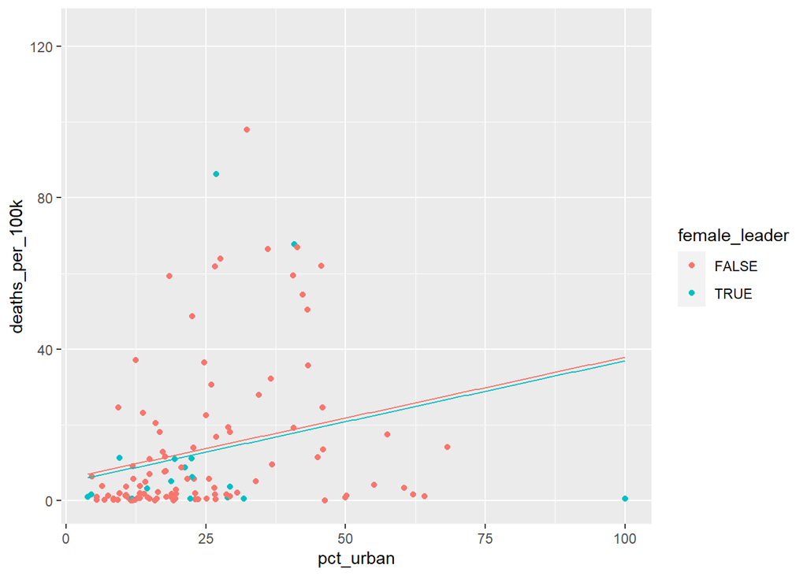

```r
# This chunk of code is used to plot the data in a more comprehensive and aesthetic way
require(ggplot2)
eq1=function(x){coef(lm.fit)[2]*x+coef(lm.fit)[1]}
eq2=function(x){coef(lm.fit)[2]*x+coef(lm.fit)[1]+coef(lm.fit)[3]}

ggplot(covid_data,aes(y=deaths_per_100k,x=pct_urban,color=female_leader))+geom_point()+
    stat_function(fun=eq1,geom="line",color=scales::hue_pal()(2)[1])+
    stat_function(fun=eq2,geom="line",color=scales::hue_pal()(2)[2])
```

- **Residual Standard Error (RSE) analysis:**

**Here the model is giving us a RSE of 20.29. To interpret this data we need to have more information on the average value of “deaths_per_100k”. Instead of plotting every value we just want to first see the mean:**

```r
# The "complete.cases" function filters out every NA from the dataset
mean(covid_data[complete.cases(covid_data),"deaths_per_100k"])
```

```
## [1] 14.23566
```

**Based on the RSE, actual data deviates from the model by 20.29 on average, which is very large compared to the mean value of 14.23. This further proves the inadequacy of the model to fit represent the reality of covid deaths.**

#### b. Fit a second model which includes the *interaction* between `pct_urban` and `female_leader`. Interpret the coefficients in this new model. Does the effect pf `pct_urban` depend on whether a country has a female president or prime minister?

- **Code**

```r
# Compared to the first question, we use the "*" operator to
lm.fit <- lm(deaths_per_100k ~ pct_urban * female_leader, data = covid_data)

# We use the summary function to show the results
summary(lm.fit)
```

```
##
## Call:
## lm(formula = deaths_per_100k ~ pct_urban * female_leader, data = covid_data)
##
## Residuals:
##     Min      1Q  Median      3Q     Max
## -28.117 -10.218  -6.957   1.277  81.278
##
## Coefficients:
##                             Estimate Std. Error t value Pr(>|t|)
## (Intercept)                   3.9450     3.9857   0.990  0.32441
## pct_urban                     0.3961     0.1385   2.860  0.00506 **
## female_leaderTRUE             6.2805     8.6723   0.724  0.47045
## pct_urban:female_leaderTRUE  -0.2891     0.2728  -1.060  0.29154
## ---
## Signif. codes:  0 '***' 0.001 '**' 0.01 '*' 0.05 '.' 0.1 ' ' 1
##
## Residual standard error: 20.28 on 112 degrees of freedom
##   (64 observations effacées parce que manquantes)
## Multiple R-squared:  0.06984,    Adjusted R-squared:  0.04492
## F-statistic: 2.803 on 3 and 112 DF,  p-value: 0.04313
```

- **Coefficients analysis**

*We suppose that every variables other than the one mentioned stay constant.*

**Compared to the previous model, the `pct_urban` coefficient does not change much, meaning its impact is relatively similar on its own. However, we can see that the `female_leader` coefficient jumped from a negative to a very high 6.28. With just these elements we could think that having a female leader suddenly increases the deaths by 6, but we cannot conclude just yet, because we need to take into account a new coefficient.**

**`pct_urban * female_leader`: this coefficient represents the relationship between the two data, and is equal to -0.289. When `female_leader` is FALSE (meaning, equal to 0), it does not intervene. But in the case of a country with a female leader, each time `pct_urban` gains a point, the number of death is expected to reduce by 0.289.**

**What this means is that, having a female leader has a negative impact on deaths number in countries with low urban population, but with countries with a `pct_urban` above around 21, having a female leader has a positive impact.**

#### c. Are either of the two models you estimated preferable as a predictive model? Why?

**I do not think either of the two models is useful as a predictive model. We already saw why the first one is not a good fit.**

#### d. Pick one further explanatory variable from the data to include in addition to the variables included in your answer to question 2. Interpret the relevant coefficient(s) on the new variable that you include and describe whether your new model improves on the predictive power of the two previous models.

**I chose to add the variable `ghs_index` because I think how prepared a country is has a big impact on the consequences of a pandemic. I add this variable to the model built in the previous question and output the summary to compare the results.**

- **Code**

```r
lm.fit <- lm(deaths_per_100k ~ pct_urban * female_leader + ghs_index, data = covid_data)

# We use the summary function to show the results
summary(lm.fit)
```

```
##
## Call:
## lm(formula = deaths_per_100k ~ pct_urban * female_leader + ghs_index,
##     data = covid_data)
##
## Residuals:
##     Min      1Q  Median      3Q     Max
## -34.942  -9.192  -4.499   2.211  79.577
##
## Coefficients:
##                             Estimate Std. Error t value Pr(>|t|)
## (Intercept)                 -14.6876     5.9694  -2.460 0.015416 *
## pct_urban                     0.2017     0.1388   1.453 0.149147
## female_leaderTRUE            -1.6916     8.3821  -0.202 0.840434
## ghs_index                     0.5411     0.1351   4.006 0.000112 ***
## pct_urban:female_leaderTRUE  -0.1534     0.2583  -0.594 0.553951
## ---
## Signif. codes:  0 '***' 0.001 '**' 0.01 '*' 0.05 '.' 0.1 ' ' 1
##
## Residual standard error: 19.04 on 111 degrees of freedom
##   (64 observations effacées parce que manquantes)
## Multiple R-squared:  0.1873, Adjusted R-squared:  0.1581
## F-statistic: 6.397 on 4 and 111 DF,  p-value: 0.0001139
```

- **Conclusion**

**The first observation is that this new variable has a much higher significance than the older ones, being less than 0.001. It is encouraging because it means this variable might explain the data better.**

**These elements suggest that this variable is more relevant than the previous ones to describe what is happening. However it still has limits, as the RSE is still very high compared to the actual values.**

## Question 2 (40 points)

Can we predict whether individuals would like their country to leave the European Union? This question uses a dataset which includes several variables taken from the 2016 European Social Survey [(https://www.europeansocialsurvey.org)](https://www.europeansocialsurvey.org). The unit of analysis is individual respondents to a face-to-face survey. There are a total of 13075 observations in the data, with respondents surveyed in 17 different European countries.

The data includes the following variables:

ESS codebook

| **Variable** | **Description** |
| --- | --- |
| `country_code` | The country of the respondent |
| `leave` | 1 if the respondent would vote to leave the European Union in a referendum, 0 otherwise |
| `gender` | Whether the respondent is male or female |
| `age` | The age of the respondent (in years) |
| `years_education` | The number of years of education the respondent has completed |
| `unemployed` | 1 if the respondent is unemployed, 0 otherwise |
| `income` | 1 if the respondent earns above the median income in their country, 0 otherwise |
| `religion` | Categorical variable of the religion of the respondent |
| `trade_union` | 1 if the respondent is a member of a trade union, 0 otherwise |
| `news_consumption` | Amount of time the respondent spends reading newspapers/online news each week (in minutes) |
| `trust_people` | The degree to which the respondent trusts other people (0 = low trust, 10 = high trust) |
| `trust_politicians` | The degree to which the respondent trusts politicians (0 = low trust, 10 = high trust) |
| `past_vote` | 1 if the respondent voted in the last general election in their country, 0 otherwise |
| `immig_econ` | The respondent’s view of the economic effects of immigration in their country (0 = Immigration is bad for the economy; 10 = Immigration is good for the economy) |
| `immig_culture` | The respondent’s view of the cultural effects of immigration in their country (0 = Immigration undermines the country’s culture; 10 = Immigration enriches the country’s culture) |
| `country_attach` | The respondent’s emotional attachment to their country (0 = Not at all emotionally attached; 10 = Very emotionally attached) |
| `climate_change` | How worried the respondent is about climate change (1 = Not at all worried; 5 = Very worried) |
| `imp_tradition` | How important the respondent feels it is to follow traditions and customs (1 = Very important; 6 = Not at all important) |
| `imp_equality` | How important the respondent feels it is people are treated equally and have equal opportunities (1 = Very important; 6 = Not at all important) |
| `eu_integration` | The respondent’s views on European unification/integration (0 = “Unification has already gone too far”; 10 = “Unification should go much further”) |
| `train` | A variable indicating whether the respondent should be used in the training set (`TRUE`) or the test set (`FALSE`). |

You can run the following line of code in R and this will load the data directly from the course website:

```r
ess <- read.csv("https://raw.githubusercontent.com/lse-me314/lse-me314.github.io/master/data/ess.csv")

summary(ess)
```

[output not shown]

#### a. Fit a logistic regression with `leave` as the response and with `age`, `gender`, `years_education` and `income` as predictors. Produce a summary of results, and discuss the results.

- **Code**

```r
glm.fit <- glm(leave ~ age + gender + years_education + income, data = ess, family = binomial)

# We use the summary function to show the results
summary(glm.fit)
```

```
##
## Call:
## glm(formula = leave ~ age + gender + years_education + income,
##     family = binomial, data = ess)
##
## Deviance Residuals:
##     Min       1Q   Median       3Q      Max
## -0.9033  -0.6623  -0.5847  -0.5085   2.6364
##
## Coefficients:
##                  Estimate Std. Error z value Pr(>|z|)
## (Intercept)     -0.927116   0.125971  -7.360 1.84e-13 ***
## age              0.001681   0.001355   1.240   0.2148
## genderMale       0.100327   0.046347   2.165   0.0304 *
## years_education -0.048847   0.006433  -7.593 3.13e-14 ***
## income          -0.293550   0.050183  -5.850 4.93e-09 ***
## ---
## Signif. codes:  0 '***' 0.001 '**' 0.01 '*' 0.05 '.' 0.1 ' ' 1
##
## (Dispersion parameter for binomial family taken to be 1)
##
##     Null deviance: 12188  on 13074  degrees of freedom
## Residual deviance: 12027  on 13070  degrees of freedom
## AIC: 12037
##
## Number of Fisher Scoring iterations: 4
```

- **Coefficients analysis:**

**`age`: positive coefficient, which means that the older you are the more susceptible you are to want to leave.**

**`gender`: males are very slightly more prone to want to leave.**

**`years_education`: negative coefficient, the population that want to leave the most are low education ones.**

**`income`: negative coefficient, more income means more desire to stay in the EU.**

**We can see that the most notable variables are the education and the income (both having a significance at <0.001). They might have a similar effect because there is a link between the two, higher education generally means higher income.**

**From these data, I would say that the population most likely to vote to leave are the low income household.**

#### b. Calculate the predicted probability of voting to leave the EU for respondents with the following characteristics

1. A 25-year old man, with above median income, and 10 years of education

**Probability of wanting to leave the EU: 17.27%**

```r
new_data <- data.frame(age=25, gender="Male", years_education=10, income=1)
predict(glm.fit, new_data, type="response")
```

```
##         1
## 0.1726746
```

2. A 25-year old woman, with above median income, and 15 years of education

**Probability of wanting to leave the EU: 12.88%**

```r
new_data <- data.frame(age=25, gender="Female", years_education=15, income=1)
predict(glm.fit, new_data, type="response")
```

```
##         1
## 0.1288289
```

3. A 65-year old woman, with below median income, and 8 years of education

**Probability of wanting to leave the EU: 22.99%**

```r
new_data <- data.frame(age=65, gender="Female", years_education=8, income=0)
predict(glm.fit, new_data, type="response")
```

```
##         1
## 0.2299428
```

4. A 65-year old man, with below median income, and 12 years of education

**Probability of wanting to leave the EU: 21.35%**

```r
new_data <- data.frame(age=65, gender="Male", years_education=12, income=0)
predict(glm.fit, new_data, type="response")
```

```
##         1
## 0.2135435
```

Which has the highest probability of voting to leave the EU?

**The highest probability comes from n°3, the person with the lowest years of education.**

Note: To calculate predicted probabilities, you can use the `predict()` function with the argument `type = "response"`.

#### c. Using the model you estimated in part (a), calculate the predicted probability of voting to leave the EU for every observation in the data. For how many observations is this probability greater than .5?

```r
# We use the predict function but instead of giving it new data we leave it blank
# so that it will go through the ess dataset
predicted_outcome <- predict(glm.fit, type="response")

summary(predicted_outcome)
```

```
##    Min. 1st Qu.  Median    Mean 3rd Qu.    Max.
## 0.03029 0.14347 0.17187 0.17652 0.20655 0.33501
```

**As we can see the maximum probability is 33.50%, which would mean that no value exceed 0.5. Just to be sure we try to count every value above 0.5:**

```r
predicted_final <- as.numeric(predicted_outcome >= 0.5)
summary(predicted_final)
```

```
##    Min. 1st Qu.  Median    Mean 3rd Qu.    Max.
##       0       0       0       0       0       0
```

#### d. Estimate a new logistic regression model, with the same covariates you included before but here also add `country_code`. Calculate the predicted probabilites for each observation in your data, and use these to compute the confusion matrix. What percentage of observations are correctly classified? How many false positives and false negatives are there in this case?

- **Code**

```r
glm.fit <- glm(leave ~ age + gender + years_education + income + country_code, data = ess, family = binomial)

# We use the summary function to show the results
summary(glm.fit)
```

```
##
## Call:
## glm(formula = leave ~ age + gender + years_education + income +
##     country_code, family = binomial, data = ess)
##
## Deviance Residuals:
##     Min       1Q   Median       3Q      Max
## -1.6084  -0.6589  -0.5019  -0.3876   2.7931
##
## Coefficients:
##                  Estimate Std. Error z value Pr(>|z|)
## (Intercept)     -0.281789   0.152544  -1.847 0.064709 .
## age             -0.001382   0.001404  -0.984 0.325220
## genderMale       0.159959   0.048020   3.331 0.000865 ***
## years_education -0.061064   0.007128  -8.566  < 2e-16 ***
## income          -0.307726   0.052396  -5.873 4.28e-09 ***
## country_codeBE  -0.638709   0.134686  -4.742 2.11e-06 ***
## country_codeCZ   0.094812   0.154489   0.614 0.539405
## country_codeDE  -0.877954   0.121351  -7.235 4.66e-13 ***
## country_codeES  -1.495269   0.165222  -9.050  < 2e-16 ***
## country_codeFI   0.083202   0.109973   0.757 0.449310
## country_codeFR  -0.133609   0.113270  -1.180 0.238172
## country_codeGB   1.171934   0.111439  10.516  < 2e-16 ***
## country_codeHU  -0.423864   0.157732  -2.687 0.007205 **
## country_codeIE  -0.905194   0.119747  -7.559 4.05e-14 ***
## country_codeIT  -0.003440   0.110559  -0.031 0.975175
## country_codeLT  -0.927504   0.128000  -7.246 4.29e-13 ***
## country_codeNL  -0.261671   0.147323  -1.776 0.075705 .
## country_codePL  -1.031478   0.136406  -7.562 3.97e-14 ***
## country_codePT  -0.857405   0.137659  -6.228 4.71e-10 ***
## country_codeSE   0.115648   0.135450   0.854 0.393212
## country_codeSI  -0.378935   0.134275  -2.822 0.004771 **
## ---
## Signif. codes:  0 '***' 0.001 '**' 0.01 '*' 0.05 '.' 0.1 ' ' 1
##
## (Dispersion parameter for binomial family taken to be 1)
##
##     Null deviance: 12188  on 13074  degrees of freedom
## Residual deviance: 11322  on 13054  degrees of freedom
## AIC: 11364
##
## Number of Fisher Scoring iterations: 5
```

**We can see that some country code have a very high significance, which can explain why the probabilities of the old model were strangely capping at 33%, maybe there were not enough data to differentiate properly the votes.**

```r
predicted_outcome <- predict(glm.fit, type="response")
predicted_final <- as.numeric(predicted_outcome >= 0.5)

summary(predicted_final)
```

```
##    Min. 1st Qu.  Median    Mean 3rd Qu.    Max.
## 0.00000 0.00000 0.00000 0.02096 0.00000 1.00000
```

**Now that we have our prediction formatted, we can compute our confusion matrix by comparing the result to the original dataset:**

```r
confusion_matrix <- table(predicted_final, ess$leave)
confusion_matrix
```

```
##
## predicted_final     0     1
##               0 10645  2156
##               1   122   152
```

```r
TN_nb <- confusion_matrix[1]
FN_nb <- confusion_matrix[2]
FP_nb <- confusion_matrix[3]
TP_nb <- confusion_matrix[4]

tot <- TN_nb + FN_nb + FP_nb + TP_nb
```

```r
(TN_nb + TP_nb) / tot
```

```
## [1] 0.8257744
```

**In this case we can see that 82.58% of cases are correctly classified.**

[output not shown]

[output not shown]